# 💃 Submission #2: Dance Move Classification using Scikit-learn

## 📘 Intro / Overview

**Welcome to our team project Submission #2.**

In this notebook, we set out to classify basic dance movements using a machine learning pipeline built with Scikit-learn. Our input data consists of human pose keypoints extracted using OpenPose, which outputs 2D joint coordinates per frame.

We collaborated as a team—integrating work from TP01 and extending it into TP02. We transformed pose data into meaningful features, trained and evaluated classifiers, and used clustering and visualization techniques to gain further insight into how movements differ.

## 🧰 Imports and Setup

Before diving into the dataset, we imported several libraries and modules that power this notebook:

- **Scikit-learn tools** for scaling, splitting, training, and evaluating models
- **Matplotlib** for data visualization
- **NumPy and Pandas** for working with arrays and DataFrames

We also reused custom helper modules from our TP01 and TP02 work:

- `sub1_pose_utils.py` (from Ixius) gives us a full pipeline to load pose JSONs, create structured DataFrames, and extract features from raw OpenPose keypoints.
- `pose_tools_byH.py` (from Hiromi) provides utilities to compute movement vectors between poses and generate insightful visualizations.

These tools let us modularize our code and stay focused on building and improving our classification pipeline.

```python
# Core imports
import pandas as pd
import numpy as np
from sklearn.preprocessing import StandardScaler, LabelEncoder
from sklearn.model_selection import train_test_split, cross_val_score
from sklearn.metrics import confusion_matrix, classification_report, ConfusionMatrixDisplay
from sklearn.pipeline import Pipeline
from sklearn.neighbors import KNeighborsClassifier
from sklearn.svm import SVC
import matplotlib.pyplot as plt
import os
```

```python
# Custom helper functions from TP01
from sub1_pose_utils import (
    index_poses, get_pose_names, read_all_poses,
    generate_column_labels, prep_dataframe,
    store_all_poses, coords_to_vectors
)
```

```python
# Import Hiromi's pose tools
from pose_tools_byH import pose_to_df, poses_to_vectors, pose_list_to_vector_df, generate_vector_graph
```

## 📥 Step 1: Load and Structure Pose Data

**Loading and Labeling Pose Data**

We used the `sub1_pose_utils.py` module (from Ixius's TP01 work) to index pose files and convert them into numerical vectors. Each `.json` filename contains a label prefix (e.g., "dance", "jumping"), which we automatically extracted using a helper function. This allowed us to programmatically assign class labels for supervised learning without hardcoding. We wrote a small helper function `extract_labels_from_filenames()` to pull class labels from JSON filenames like `dance_01.json` → `"dance"`.

Thanks to Hiromi’s pose file naming and organization, we were able to fully automate label generation from filenames.

```python
# Load Pose JSONs
json_list = index_poses("poses")
pose_names = get_pose_names(json_list)
pose_list = read_all_poses(json_list, dir_path="poses")
```

**Pose Augmentation: Mirroring and Jittering**

We wrote a custom script (`augment_poses.py`) to generate additional training data by:

- **Mirroring**: flipping left/right limbs
- **Jittering**: adding small noise to joint positions

These new `.json` files were saved directly into the `poses/` folder, which allowed us to reuse the TP01-style loading code without changes.

```python
## Label Extraction from Filenames
def extract_labels_from_filenames(json_list):
    """Extracts labels from filenames using the prefix before underscore.
    E.g., 'dance_01.json' → 'dance' """
    return [fname.split('_')[0] for fname in json_list]
```

**Encoding Labels**

Once we extracted the prefix from each filename, we encoded the class names using `LabelEncoder` to convert them into integer values for training.

```python
# Generate Class Labels from Filenames
labels_raw = extract_labels_from_filenames(json_list)
```

```python
# Build DataFrame
labels = generate_column_labels()
df = prep_dataframe(labels)
store_all_poses(pose_list, labels, df)
```

**Integrating Submission #1 Pandas: Coordinate-Based Feature Matrix**

To maintain continuity with our earlier TP01 work, we used `sub1_pose_utils.py` to generate a full DataFrame (`df`) of raw 2D joint coordinates. This preserves the structure and functionality of our original pose loader.

Although we no longer use this `df` directly for model training, we include it here for comparison and traceability. It demonstrates the structure and completeness of the dataset before transitioning to motion-based features.

```python
print("Data shape:", df.shape)
df.head()
```

```
Data shape: (138, 36)
```

|  | 00x | 00y | 01x | 01y | 02x | 02y | 03x | 03y | 04x | 04y | ... | 13x | 13y | 14x | 14y | 15x | 15y | 16x | 16y | 17x | 17y |
| --- | --- | --- | --- | --- | --- | --- | --- | --- | --- | --- | --- | --- | --- | --- | --- | --- | --- | --- | --- | --- | --- |
| 0 | 416.970074 | 111.688862 | 395.498931 | 200.326142 | 343.197430 | 201.977769 | 266.121535 | 255.930896 | 174.731544 | 308.782939 | ... | 278.233461 | 650.119049 | 402.655979 | 103.981273 | 413.666821 | 102.880188 | 367.421283 | 120.497536 | 399.352726 | 116.093199 |
| 1 | 419.812275 | 112.389414 | 396.379793 | 198.807795 | 344.696961 | 201.544202 | 266.964600 | 257.191731 | 174.065116 | 309.088476 | ... | 280.867469 | 651.334990 | 406.699721 | 102.593387 | 417.097917 | 98.816659 | 363.134732 | 121.148660 | 394.973894 | 114.855606 |
| 2 | 351.029926 | 111.688862 | 372.501069 | 200.326142 | 320.199568 | 198.674516 | 278.358367 | 263.638486 | 286.065957 | 335.208960 | ... | 317.997399 | 680.949408 | 365.344021 | 103.981273 | 354.333179 | 102.880188 | 400.578717 | 120.497536 | 368.647274 | 116.093199 |
| 3 | 370.682954 | 112.752594 | 397.372456 | 176.547014 | 332.927073 | 176.547014 | 239.188333 | 210.397114 | 180.601621 | 125.771863 | ... | 442.288935 | 690.808154 | 357.663684 | 101.035252 | 382.400296 | 94.525617 | 348.550196 | 104.941032 | 416.250397 | 90.619836 |
| 4 | 371.664517 | 109.737963 | 400.616173 | 176.191353 | 334.625176 | 176.672433 | 239.893688 | 210.605581 | 182.509766 | 121.327218 | ... | 447.019631 | 692.980378 | 354.914058 | 101.305644 | 381.810578 | 98.327244 | 350.047405 | 104.670495 | 415.787256 | 91.122942 |

5 rows × 36 columns

## 🧹 Step 2: Preprocessing: Cleaning, Scaling, and Encoding

Before training our models, we cleaned and transformed our data:

- `df.dropna()` removes any poses that were missing joint data
- `StandardScaler()` normalizes our features to improve model performance
- `LabelEncoder()` converts string-based labels (like `"dance"`) into integers Scikit-learn can use

These steps ensure that our input matrix `X` and label vector `y` are clean, scaled, and aligned.

```python
# Clean missing rows (TP01 Logic)
df.dropna(inplace=True)
```

```python
# Normalize features
scaler = StandardScaler()
```

```python
# Encode class labels (e.g., 'dance', 'jumping', etc.) into numeric form
label_encoder = LabelEncoder()
y = label_encoder.fit_transform(labels_raw)

labels_raw_trimmed = labels_raw[:-1]  # remove last label
y = label_encoder.fit_transform(labels_raw_trimmed)

print("Label classes:", label_encoder.classes_)
```

```
Label classes: ['dance' 'flexing' 'jumping' 'laying' 'sitting' 'standing' 'tpose']
```

## 🛠️ Step 3: Feature Engineering with Pose Vectors

After loading and labeling our pose data, we needed a way to convert these static 2D keypoints into meaningful features for classification.

Rather than relying on raw coordinates, we used Hiromi’s toolkit `pose_tools_byH.py`, which includes the function `pose_list_to_vector_df()`. This converts consecutive poses into motion vectors that represent joint movement—enabling our model to learn from how the body moves, not just where it is.

We then scaled the resulting `vectors_df` using Scikit-learn’s `StandardScaler()` to normalize across joint dimensions, ensuring the features are suitable for distance-based models like KNN and SVC.

> 📌 From this point on, we use `vectors_df` exclusively as our feature matrix (`X`) for classification.

```python
# Recalculate X as movement vectors between pose pairs
vectors_df = pose_list_to_vector_df(pose_list, labels)
X = scaler.fit_transform(vectors_df.values)
```

## ✂️ Step 4: Train / Test Split

```python
# Split data
X_train, X_test, y_train, y_test = train_test_split(X, y, test_size=0.2, random_state=42)
```

## 🛰️ Step 5: Visualize Feature Space

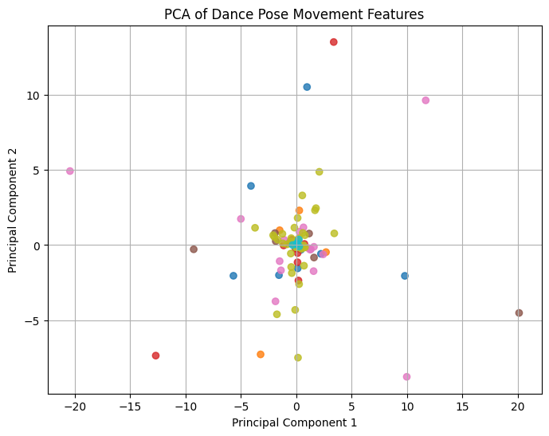

```python
# Visualize feature space using PCA
from sklearn.decomposition import PCA

pca = PCA(n_components=2)
X_2D = pca.fit_transform(X)

plt.figure(figsize=(8, 6))
plt.scatter(X_2D[:, 0], X_2D[:, 1], c=y, cmap='tab10', alpha=0.8)
plt.title("PCA of Dance Pose Movement Features")
plt.xlabel("Principal Component 1")
plt.ylabel("Principal Component 2")
plt.grid(True)
plt.show()
```

## 🤖 Step 6: Supervised Learning Models

**Training Classifiers: KNN and SVC**

We trained both a **K-Nearest Neighbors (KNN)** model and a **Support Vector Classifier (SVC)**.

```python
from collections import Counter
print("Training label distribution:", Counter(y_train))
print("Test label distribution:", Counter(y_test))
```

```
Training label distribution: Counter({5: 47, 4: 22, 0: 13, 2: 11, 3: 7, 1: 6, 6: 3})
Test label distribution: Counter({5: 10, 4: 5, 2: 4, 1: 3, 0: 2, 6: 2, 3: 2})
```

```python
# K-Nearest Neighbors
knn = KNeighborsClassifier(n_neighbors=3)
knn.fit(X_train, y_train)
y_pred_knn = knn.predict(X_test)
print("KNN Accuracy:", knn.score(X_test, y_test))
```

```
KNN Accuracy: 0.25
```

## 🕵️ Step 7: Visualize Pose Movement

**Pose Comparison: Original vs. Mirrored vs. Jittered**

This 3-panel subplot shows movement vectors between pose pairs of three types:

- **Original** poses (left): minimal or no visible movement.
- **Mirrored** poses (center): reflected across the vertical axis with noticeable left-right symmetry.
- **Jittered** poses (right): include small, randomized noise to simulate variability in joint detection.

Each vector arrow represents the change in position from pose A to pose B for each joint. This visualization helps demonstrate how our augmentation strategy introduces meaningful variation while preserving structural similarity.

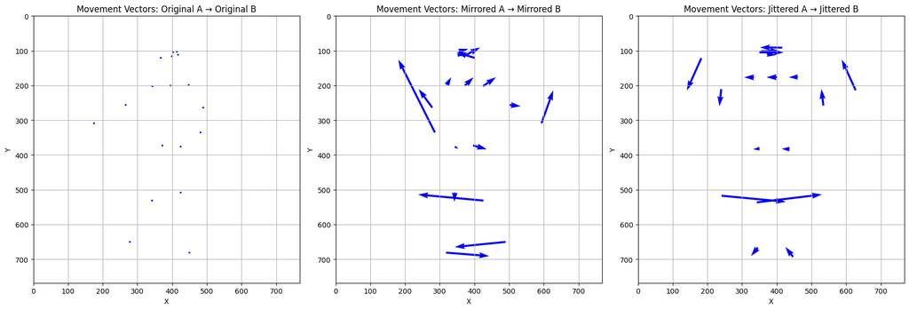

```python
# # Visualize the movement between the first two poses
# generate_vector_graph(
#     pose_list[0],
#     poses_to_vectors(pose_list[0], pose_list[1]),
#     pose_name1=pose_names[0],
#     pose_name2=pose_names[1]
# )

fig, axes = plt.subplots(1, 3, figsize=(18, 6))

# Choose any 3 meaningful pairs
pairs = [(0, 1), (2, 3), (4, 5)]
titles = [("Original A", "Original B"), ("Mirrored A", "Mirrored B"), ("Jittered A", "Jittered B")]

for ax, (i, j), (title1, title2) in zip(axes, pairs, titles):
    pose = pose_list[i]
    next_pose = pose_list[j]
    movement = poses_to_vectors(pose, next_pose)
    generate_vector_graph(pose, movement, pose_name1=title1, pose_name2=title2, ax=ax)

plt.tight_layout()
plt.show()
```

**Reflection on Toolkit Integration**

Our final classifier pipeline combines tools from both TP01 and TP02:

- **TP01 (`sub1_pose_utils.py`)**: robust pose loading, labeling, and DataFrame generation
- **TP02 (`pose_tools_byH.py`)**: advanced movement vector extraction and visual validation

## 🤖 Step 8: Unsupervised Learning: Clustering with KMeans and GMM

To explore structure in our feature space, we applied:

- **KMeans** clustering (hard boundaries)
- **Gaussian Mixture Models** (soft probability clusters)

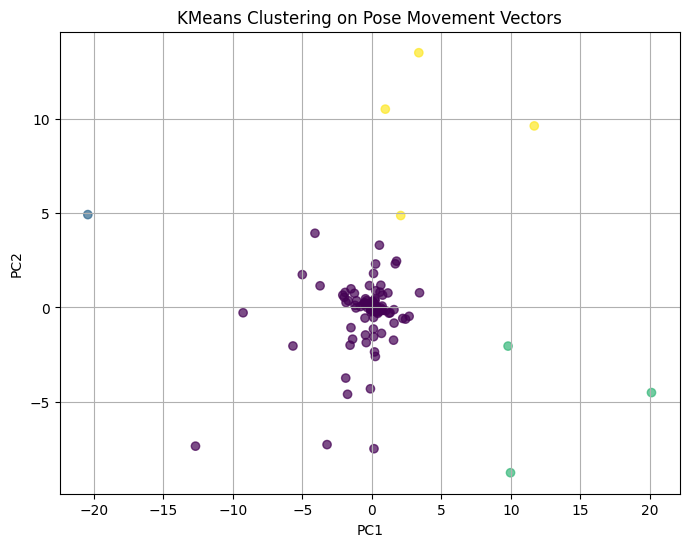

```python
from sklearn.cluster import KMeans
from sklearn.decomposition import PCA
import matplotlib.pyplot as plt

# Reduce feature space for visualization
pca = PCA(n_components=2)
X_2D = pca.fit_transform(X)

# Apply KMeans clustering
kmeans = KMeans(n_clusters=4, random_state=42)
clusters = kmeans.fit_predict(X)

# Plot the clusters
plt.figure(figsize=(8, 6))
plt.scatter(X_2D[:, 0], X_2D[:, 1], c=clusters, cmap='viridis', alpha=0.7)
plt.title("KMeans Clustering on Pose Movement Vectors")
plt.xlabel("PC1")
plt.ylabel("PC2")
plt.grid(True)
plt.show()
```

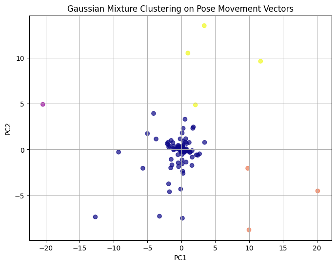

```python
from sklearn.mixture import GaussianMixture

# Apply GMM clustering
gmm = GaussianMixture(n_components=4, random_state=42)
gmm_labels = gmm.fit_predict(X)

# Plot the GMM clusters
plt.figure(figsize=(8, 6))
plt.scatter(X_2D[:, 0], X_2D[:, 1], c=gmm_labels, cmap='plasma', alpha=0.7)
plt.title("Gaussian Mixture Clustering on Pose Movement Vectors")
plt.xlabel("PC1")
plt.ylabel("PC2")
plt.grid(True)
plt.show()
```

## 🧪 Step 9: Evaluate Model Performance

**Evaluation and Class Imbalance**

Our original dataset was imbalanced, with class `5` dominating. After augmenting poses with mirrored and jittered versions, we reran training and evaluation. Confusion matrices revealed better class distribution, but some minority classes were still misclassified.

This demonstrated the importance of balancing datasets before expecting strong generalization from ML models.

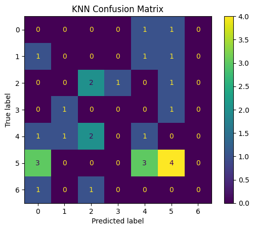

```
              precision    recall  f1-score   support

           0       0.00      0.00      0.00         2
           1       0.00      0.00      0.00         3
           2       0.40      0.50      0.44         4
           3       0.00      0.00      0.00         2
           4       0.17      0.20      0.18         5
           5       0.50      0.40      0.44        10
           6       0.00      0.00      0.00         2

    accuracy                           0.25        28
   macro avg       0.15      0.16      0.15        28
weighted avg       0.27      0.25      0.25        28
```

```python
# Confusion Matrix
ConfusionMatrixDisplay.from_predictions(y_test, y_pred_knn)
plt.title("KNN Confusion Matrix")
plt.show()

# Classification report
print(classification_report(y_test, y_pred_knn))
```

## 🧬 Step 10: Add Model for Comparison (optional)

```
Balanced SVC Accuracy: 0.21428571428571427
              precision    recall  f1-score   support

           0       0.00      0.00      0.00         2
           1       0.00      0.00      0.00         3
           2       0.00      0.00      0.00         4
           3       0.00      0.00      0.00         2
           4       0.50      0.20      0.29         5
           5       0.43      0.30      0.35        10
           6       0.12      1.00      0.21         2

    accuracy                           0.21        28
   macro avg       0.15      0.21      0.12        28
weighted avg       0.25      0.21      0.19        28
```

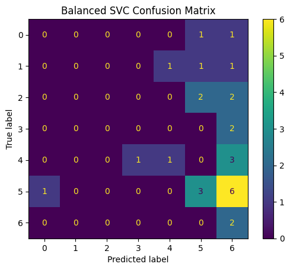

```python
# Compare with SVC classifier
from sklearn.svm import SVC

#svc = SVC(kernel='rbf')  # overfit dominant class (class 5), Accuracy: ~66.7%
svc = SVC(kernel="rbf", class_weight="balanced", random_state=42)
svc.fit(X_train, y_train)
y_pred_svc = svc.predict(X_test)

# print("SVC Accuracy:", svc.score(X_test, y_test))
print("Balanced SVC Accuracy:", svc.score(X_test, y_test))

# print(classification_report(y_test, y_pred_svc))
print(classification_report(y_test, y_pred_svc, zero_division=0))

ConfusionMatrixDisplay.from_predictions(y_test, y_pred_svc) # Unbalanced only predicted class 5, even when other classes in test set

# plt.title("SVC Confusion Matrix")
plt.title("Balanced SVC Confusion Matrix")

plt.show()
```

## 🎓 Summary

In this tutorial, we demonstrated how to classify human dance movements using pose vectors extracted from JSON data. We used Scikit-learn to implement a KNN classifier and evaluated its performance using a confusion matrix and classification report. We also visualized motion between poses using vector arrows and explored dimensionality with PCA. Our data pipeline and labeling strategy were built collaboratively, and we extend special thanks to Hiromi Cota for their work on initial dataset structure and visualization tools.

## 🎓 What We Learned

This tutorial helped us build an end-to-end Scikit-learn pipeline and reinforced the importance of good data practices.

In future work, we’d love to try:

- Real-time classification via webcam
- Deep learning (e.g., LSTM or CNN for movement sequences)
- Larger pose datasets from Kaggle or CMU’s motion capture library

## 🎓 Conclusion & Next Steps

In this tutorial, we demonstrated a multi-class classification of dance moves using Scikit-learn. We began by loading pose data, engineered features from keypoints, and trained a basic KNN model.

✅ Next steps might include:

- Using real class labels (e.g., "step", "spin", "slide")
- Adding additional models (e.g., SVM with kernel tuning)

🧠 Stay tuned for TP03: Deep Learning with PyTorch!

## References

- Matthes, E. (2023). *Python Crash Course* (3rd ed.). No Starch Press.
- Microsoft. (2025). *Fundamentals of Generative AI*. Microsoft Learn. https://learn.microsoft.com
- OpenAI. (2025). ChatGPT’s assistance with Scikit-learn dance classification [Large language model]. https://openai.com/chatgpt
- Scikit-learn. (n.d.). User guide. https://scikit-learn.org/stable/user_guide.html